# Ch9_IntroToWrangling

Steve Newns

October 13, 2017

Data wrangling = **art** of getting data into a useful form for visualisation + modeling.

- w/out wrangling –> can’t work w/ your own data!

3 main parts to data wrangling:

- Import
- Tidy
- consistent way of storing data that makes transorms, viz, + modeling easier
- Transform

4 specific types of data frequently encountered in practice:

- relational = interelated datasets
- string = including RegEx
- factors = categorical data w/ fixed set of possible values
- date/time

# CHAPTER 10 - TIBBLES

**Tibbles** = data frames, but w/ tweaked older behaviours to make life a little easier than w/ `data.frame`

R = old language + some things useful 10/20 years ago now get in the way + it’s difficult to change base R w/out breaking existing code ==> most innovation occurs in **packages**.

`tibble` package provides opinionated data frames that make working in the tidyverse a little easier

To learn more about tibbles, look at `vignette("tibble")`.

tibbles = 1 of the unifying features of tidyverse + most other R packages use regular data frames

To coerce a data frame to a tibble –> `as_tibble()`:

```r
as.tibble(iris)
```

```
## # A tibble: 150 x 5
##    Sepal.Length Sepal.Width Petal.Length Petal.Width Species
##           <dbl>       <dbl>        <dbl>       <dbl>  <fctr>
##  1          5.1         3.5          1.4         0.2  setosa
##  2          4.9         3.0          1.4         0.2  setosa
##  3          4.7         3.2          1.3         0.2  setosa
##  4          4.6         3.1          1.5         0.2  setosa
##  5          5.0         3.6          1.4         0.2  setosa
##  6          5.4         3.9          1.7         0.4  setosa
##  7          4.6         3.4          1.4         0.3  setosa
##  8          5.0         3.4          1.5         0.2  setosa
##  9          4.4         2.9          1.4         0.2  setosa
## 10          4.9         3.1          1.5         0.1  setosa
## # ... with 140 more rows
```

Create new tibbles from individual vectors w/ `tibble()`

```r
tibble(x = 1:5, y = 1, z = x^2 + y) # y will be recycled
```

```
## # A tibble: 5 x 3
##       x     y     z
##   <int> <dbl> <dbl>
## 1     1     1     2
## 2     2     1     5
## 3     3     1    10
## 4     4     1    17
## 5     5     1    26
```

`tibble()` does less than `data.frame()` –> never changes the inputs type (e.g. never converts strings to factors), never changes variable names, + never creates row names.

It’s possible for a tibble to have column names that are *not* valid R variable names (aka **non-syntactic names** = might not start w/ a letter, or might contain unusual characters like a space). To refer to these variables, you need to surround them with backticks:

- will also need backticks when working w/ these variables in other packages, like ggplot2, dplyr, and tidyr.

```r
tibble(`:)` = "smile", ` ` = "space", `2000` = "number")
```

```
## # A tibble: 1 x 3
##    `:)`   ` ` `2000`
##   <chr> <chr>  <chr>
## 1 smile space number
```

Another way to create a tibble = `tribble()` = short for **transposed tibble** + is customised for data entry in code w/ column headings defined by formulas (start w/ ~) + entries are separated by commas. This makes it possible to lay out small amounts of data in easy to read form.

```r
tribble(~x, ~y, ~z,
        #--/--/----
        "a", 2, 3.6,
        "b", 1, 8.5)
```

```
## # A tibble: 2 x 3
##       x     y     z
##   <chr> <dbl> <dbl>
## 1     a     2   3.6
## 2     b     1   8.5
```

2 main differences in usage of a `tibble` vs. a classic `data.frame`: **printing** and **subsetting**.

## Printing

Tibbles show only the 1st 10 rows + all columns that can fit on screen (as well as their types, as if w/ `str`) = makes it much easier to work w/ large data.

```r
tibble(a = lubridate::now() + runif(1e3) * 86400,
       b = today() + runif(1e3) * 30,
       c = 1:1e3, # integers 1 - 1000
       d = runif(1e3), # generate 1000 random deviations from the uniform distribution
       e = sample(letters, 1e3, replace = T)) # use built-in roman alphabet constants + sample 1000 of time
```

```
## # A tibble: 1,000 x 5
##                      a          b     c         d     e
##                 <dttm>     <date> <int>     <dbl> <chr>
##  1 2017-10-17 16:12:29 2017-11-13     1 0.6130057     p
##  2 2017-10-17 15:03:23 2017-11-03     2 0.4539453     a
##  3 2017-10-17 06:08:05 2017-10-18     3 0.5180247     o
##  4 2017-10-17 08:10:30 2017-11-08     4 0.5205815     i
##  5 2017-10-17 03:17:39 2017-10-28     5 0.6273689     y
##  6 2017-10-17 14:59:12 2017-11-08     6 0.8198421     w
##  7 2017-10-17 00:48:17 2017-10-28     7 0.2944310     k
##  8 2017-10-17 01:04:59 2017-10-25     8 0.8418854     t
##  9 2017-10-17 06:30:34 2017-10-19     9 0.6314921     r
## 10 2017-10-17 07:14:58 2017-11-09    10 0.6764674     d
## # ... with 990 more rows
```

Tibbles = designed so you don’t accidentally overwhelm the console by printing large data frames. But sometimes you need more output than the default display, + there are a few options that can help.

Can explicitly `print()` the data frame + control the # of rows (**n**) + the width of the display, such as **width = Inf** to display all columns:

```r
nycflights13::flights %>%
  print(n = 10, width = Inf)
```

```
## # A tibble: 336,776 x 19
##     year month   day dep_time sched_dep_time dep_delay arr_time sched_arr_time arr_delay carrier flight tailnum origin  dest air_time distance  hour minute           time_hour
##    <int> <int> <int>    <int>          <int>     <dbl>    <int>          <int>     <dbl>   <chr>  <int>   <chr>  <chr> <chr>    <dbl>    <dbl> <dbl>  <dbl>              <dttm>
##  1  2013     1     1      517            515         2      830            819        11      UA   1545  N14228    EWR   IAH      227     1400     5     15 2013-01-01 05:00:00
##  2  2013     1     1      533            529         4      850            830        20      UA   1714  N24211    LGA   IAH      227     1416     5     29 2013-01-01 05:00:00
##  3  2013     1     1      542            540         2      923            850        33      AA   1141  N619AA    JFK   MIA      160     1089     5     40 2013-01-01 05:00:00
##  4  2013     1     1      544            545        -1     1004           1022       -18      B6    725  N804JB    JFK   BQN      183     1576     5     45 2013-01-01 05:00:00
##  5  2013     1     1      554            600        -6      812            837       -25      DL    461  N668DN    LGA   ATL      116      762     6      0 2013-01-01 06:00:00
##  6  2013     1     1      554            558        -4      740            728        12      UA   1696  N39463    EWR   ORD      150      719     5     58 2013-01-01 05:00:00
##  7  2013     1     1      555            600        -5      913            854        19      B6    507  N516JB    EWR   FLL      158     1065     6      0 2013-01-01 06:00:00
##  8  2013     1     1      557            600        -3      709            723       -14      EV   5708  N829AS    LGA   IAD       53      229     6      0 2013-01-01 06:00:00
##  9  2013     1     1      557            600        -3      838            846        -8      B6     79  N593JB    JFK   MCO      140      944     6      0 2013-01-01 06:00:00
## 10  2013     1     1      558            600        -2      753            745         8      AA    301  N3ALAA    LGA   ORD      138      733     6      0 2013-01-01 06:00:00
## # ... with 3.368e+05 more rows
```

Can also control default print behaviour by setting options:

- `options(tibble.print_max = n, tibble.print_min = m)`: if there are more than m rows, print only n rows.
- Use `options(dplyr.print_min = Inf)` to *always* show *all rows*.
- Use `options(tibble.width = Inf)` to *always* print *all columns*, regardless of the width of the screen.

Can see a complete list of options by looking at the package help with `package?tibble`.

Final option = use RStudio’s built-in **data viewer** to get a scrollable view of the complete (often useful at the end of a long chain of manipulations)

```r
nycflights13::flights %>%
  View() # spreadsheet-like view
```

## Subsetting

To pull out a single variable –> use `$` and `[[`, where `[[` can extract by name *or* by position, while `$` only extracts by name but is a little less typing.

```r
df <- tibble(
  x = runif(5),
  y = rnorm(5)
)

# Extract by name
df$x
```

```
## [1] 0.8186153 0.7258685 0.4101873 0.9324767 0.4689018
```

```r
df[["x"]]
```

```
## [1] 0.8186153 0.7258685 0.4101873 0.9324767 0.4689018
```

```r
# Extract by position
df[[1]]
```

```
## [1] 0.8186153 0.7258685 0.4101873 0.9324767 0.4689018
```

To use these in a pipe –> need a special placeholder `.`:

```r
df %>% .$x
```

```
## [1] 0.8186153 0.7258685 0.4101873 0.9324767 0.4689018
```

```r
df %>% .[["x"]]
```

```
## [1] 0.8186153 0.7258685 0.4101873 0.9324767 0.4689018
```

Compared to `data.frame`, `tibbles` = more strict –> never do partial matching + will generate a warning if a column you’re trying to access does not exist.

## Interacting w/ Older Code

**Some older functions don’t work w/ tibbles**.

- If you encounter 1 of these functions, use `as.data.frame()` to turn a tibble back to a data.frame:

```r
tb <- tibble(
  `:)` = "smile",
  ` ` = "space",
  `2000` = "number"
)

class(tb) # error
```

```
## [1] "tbl_df"     "tbl"        "data.frame"
```

```r
class(as.data.frame(tb))
```

```
## [1] "data.frame"
```

Main reason some older functions don’t work w/ tibble = the **`[` function** –> `dplyr::filter()` + `dplyr::select()` solve the same problems w/ clearer code. In base R data frames, `[` sometimes returns a data frame, but sometimes returns a vector. W/ tibbles, `[` *always returns another tibble*.

# 10.5 Exercises

*How can you tell if an object is a tibble? (Hint: try printing mtcars, which is a regular data frame).*

- `tibbles` tell you that it’s a tibble
- We’d see only the top 10 rows and the column data types under the column names
- `data.frames` will also show the row **labels**, while `tibbles` have row numbers

```r
print(mtcars)
```

```
##                      mpg cyl  disp  hp drat    wt  qsec vs am gear carb
## Mazda RX4           21.0   6 160.0 110 3.90 2.620 16.46  0  1    4    4
## Mazda RX4 Wag       21.0   6 160.0 110 3.90 2.875 17.02  0  1    4    4
## Datsun 710          22.8   4 108.0  93 3.85 2.320 18.61  1  1    4    1
## Hornet 4 Drive      21.4   6 258.0 110 3.08 3.215 19.44  1  0    3    1
## Hornet Sportabout   18.7   8 360.0 175 3.15 3.440 17.02  0  0    3    2
## Valiant             18.1   6 225.0 105 2.76 3.460 20.22  1  0    3    1
## Duster 360          14.3   8 360.0 245 3.21 3.570 15.84  0  0    3    4
## Merc 240D           24.4   4 146.7  62 3.69 3.190 20.00  1  0    4    2
## Merc 230            22.8   4 140.8  95 3.92 3.150 22.90  1  0    4    2
## Merc 280            19.2   6 167.6 123 3.92 3.440 18.30  1  0    4    4
## Merc 280C           17.8   6 167.6 123 3.92 3.440 18.90  1  0    4    4
## Merc 450SE          16.4   8 275.8 180 3.07 4.070 17.40  0  0    3    3
## Merc 450SL          17.3   8 275.8 180 3.07 3.730 17.60  0  0    3    3
## Merc 450SLC         15.2   8 275.8 180 3.07 3.780 18.00  0  0    3    3
## Cadillac Fleetwood  10.4   8 472.0 205 2.93 5.250 17.98  0  0    3    4
## Lincoln Continental 10.4   8 460.0 215 3.00 5.424 17.82  0  0    3    4
## Chrysler Imperial   14.7   8 440.0 230 3.23 5.345 17.42  0  0    3    4
## Fiat 128            32.4   4  78.7  66 4.08 2.200 19.47  1  1    4    1
## Honda Civic         30.4   4  75.7  52 4.93 1.615 18.52  1  1    4    2
## Toyota Corolla      33.9   4  71.1  65 4.22 1.835 19.90  1  1    4    1
## Toyota Corona       21.5   4 120.1  97 3.70 2.465 20.01  1  0    3    1
## Dodge Challenger    15.5   8 318.0 150 2.76 3.520 16.87  0  0    3    2
## AMC Javelin         15.2   8 304.0 150 3.15 3.435 17.30  0  0    3    2
## Camaro Z28          13.3   8 350.0 245 3.73 3.840 15.41  0  0    3    4
## Pontiac Firebird    19.2   8 400.0 175 3.08 3.845 17.05  0  0    3    2
## Fiat X1-9           27.3   4  79.0  66 4.08 1.935 18.90  1  1    4    1
## Porsche 914-2       26.0   4 120.3  91 4.43 2.140 16.70  0  1    5    2
## Lotus Europa        30.4   4  95.1 113 3.77 1.513 16.90  1  1    5    2
## Ford Pantera L      15.8   8 351.0 264 4.22 3.170 14.50  0  1    5    4
## Ferrari Dino        19.7   6 145.0 175 3.62 2.770 15.50  0  1    5    6
## Maserati Bora       15.0   8 301.0 335 3.54 3.570 14.60  0  1    5    8
## Volvo 142E          21.4   4 121.0 109 4.11 2.780 18.60  1  1    4    2
```

```r
print(as.tibble(mtcars))
```

```
## # A tibble: 32 x 11
##      mpg   cyl  disp    hp  drat    wt  qsec    vs    am  gear  carb
##  * <dbl> <dbl> <dbl> <dbl> <dbl> <dbl> <dbl> <dbl> <dbl> <dbl> <dbl>
##  1  21.0     6 160.0   110  3.90 2.620 16.46     0     1     4     4
##  2  21.0     6 160.0   110  3.90 2.875 17.02     0     1     4     4
##  3  22.8     4 108.0    93  3.85 2.320 18.61     1     1     4     1
##  4  21.4     6 258.0   110  3.08 3.215 19.44     1     0     3     1
##  5  18.7     8 360.0   175  3.15 3.440 17.02     0     0     3     2
##  6  18.1     6 225.0   105  2.76 3.460 20.22     1     0     3     1
##  7  14.3     8 360.0   245  3.21 3.570 15.84     0     0     3     4
##  8  24.4     4 146.7    62  3.69 3.190 20.00     1     0     4     2
##  9  22.8     4 140.8    95  3.92 3.150 22.90     1     0     4     2
## 10  19.2     6 167.6   123  3.92 3.440 18.30     1     0     4     4
## # ... with 22 more rows
```

*Compare and contrast the following operations on a data.frame and equivalent tibble. What is different? Why might the default data frame behaviours cause you frustration?*

```r
df <- data.frame(abc = 1, xyz = "a") # make a 1*2 data frame
df$x
```

```
## [1] a
## Levels: a
```

```r
df[, "xyz"] # get all rows for xyz col
```

```
## [1] a
## Levels: a
```

```r
df[, c("abc", "xyz")] # get all rows for abc and xyz cols
```

```
##   abc xyz
## 1   1   a
```

```r
df <- tibble(abc = 1, xyz = "a") # make a 1*2 data frame
df$x # does not complete column name
```

[output not shown]

```r
df[, "xyz"] # get all rows for xyz col
```

```
## # A tibble: 1 x 1
##     xyz
##   <chr>
## 1     a
```

```r
df[, c("abc", "xyz")] # get all rows for abc and xyz cols
```

```
## # A tibble: 1 x 2
##     abc   xyz
##   <dbl> <chr>
## 1     1     a
```

*If you have the name of a variable stored in an object, e.g. var <- “mpg”, how can you extract the reference variable from a tibble?*

```r
var <- "xyz"

# get a tibble
df[var]
```

```
## # A tibble: 1 x 1
##     xyz
##   <chr>
## 1     a
```

```r
class(df[var])
```

```
## [1] "tbl_df"     "tbl"        "data.frame"
```

```r
# get a vector
df[[var]]
```

```
## [1] "a"
```

```r
class(df[[var]])
```

```
## [1] "character"
```

*Practice referring to non-syntactic names in the following data frame by:*

```r
annoying <- tibble(
  `1` = 1:10,
  `2` = `1` * 2 + rnorm(length(`1`))
)
```

- Extracting the variable called 1.

```r
annoying[[1]]
```

```
##  [1]  1  2  3  4  5  6  7  8  9 10
```

```r
annoying$'1'
```

```
##  [1]  1  2  3  4  5  6  7  8  9 10
```

- Plotting a scatterplot of 1 vs 2.

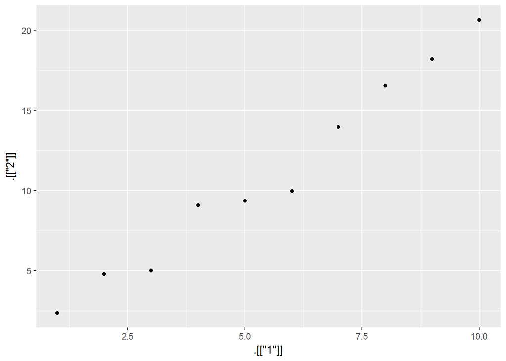

```r
annoying %>%
  ggplot(aes(.[["1"]],.[["2"]])) +
  geom_point()
```

- Creating a new column called 3 which is 2 divided by 1.

```r
(annoying <- annoying %>%
  mutate(`3` = `2` / `1`))
```

```
## # A tibble: 10 x 3
##      `1`       `2`      `3`
##    <int>     <dbl>    <dbl>
##  1     1  2.352501 2.352501
##  2     2  4.802159 2.401080
##  3     3  5.014337 1.671446
##  4     4  9.071497 2.267874
##  5     5  9.356091 1.871218
##  6     6  9.953157 1.658860
##  7     7 13.944526 1.992075
##  8     8 16.526957 2.065870
##  9     9 18.190025 2.021114
## 10    10 20.632500 2.063250
```

- Renaming the columns to one, two and three.

```r
annoying %>%
  rename(one = `1`,
         two = `2`,
         three = `3`)
```

```
## # A tibble: 10 x 3
##      one       two    three
##    <int>     <dbl>    <dbl>
##  1     1  2.352501 2.352501
##  2     2  4.802159 2.401080
##  3     3  5.014337 1.671446
##  4     4  9.071497 2.267874
##  5     5  9.356091 1.871218
##  6     6  9.953157 1.658860
##  7     7 13.944526 1.992075
##  8     8 16.526957 2.065870
##  9     9 18.190025 2.021114
## 10    10 20.632500 2.063250
```

*What does tibble::enframe() do? When might you use it?*

It converts lists or atomic vectors that have been named into 2-col data frames

```r
nums <- c('one','two',3,'four',5,'apple')
enframe(nums)
```

```
## # A tibble: 6 x 2
##    name value
##   <int> <chr>
## 1     1   one
## 2     2   two
## 3     3     3
## 4     4  four
## 5     5     5
## 6     6 apple
```

*What option controls how many additional column names are printed at the footer of a tibble?*

```r
nycflights13::flights %>%
  print(n_extra = 1)
```

```
## # A tibble: 336,776 x 19
##     year month   day dep_time sched_dep_time dep_delay arr_time
##    <int> <int> <int>    <int>          <int>     <dbl>    <int>
##  1  2013     1     1      517            515         2      830
##  2  2013     1     1      533            529         4      850
##  3  2013     1     1      542            540         2      923
##  4  2013     1     1      544            545        -1     1004
##  5  2013     1     1      554            600        -6      812
##  6  2013     1     1      554            558        -4      740
##  7  2013     1     1      555            600        -5      913
##  8  2013     1     1      557            600        -3      709
##  9  2013     1     1      557            600        -3      838
## 10  2013     1     1      558            600        -2      753
## # ... with 336,766 more rows, and 12 more variables: sched_arr_time <int>,
## #   ...
```